# BMW Price different between Electronic car and Petrol Cars by region.

Author

Jason Chen

## Introduction

The dataset used in the research is BMW sales data (2010-2024) dataset form Kaggle. This dataset includes the detail of every car BMW sold from 2010 to 2024. The detailed information include model, year, region, color, fuel type, transmission, engine size, mileage, price in USD, sales volume, and a sales classification variable. By using this dataset, with my skill on data wrangling, data virtualization and regression modeling, the research is aiming to understand BMW pricing logic, and how regional difference influence on global market pricing.

## Ethical Considerations

I think the risks of this dataset and project related to privacy or individual identification are really small, because this dataset only contains non-personal, product-level data such as model, region, and price. But I still recognize that the process of collecting data naturally contains some biases. Different regions may have varying standards of data reporting, data cleaning, or pricing documentation. So, the results from the data may show something unexpected. To remain ethically responsible, all the outcomes and illustrations in the project should be presented strictly with the evidence of the data. In the project, I shouldn’t exaggerate or ignore any data outcome in order to provide a better result.

## Data Explanation and Exploration

This dataset contains detail information of every car BMW sold from 2010 to 2024, including Model, Year, Region, Fuel_Type, Engine_Size_L, Mileage_KM, Price_USD, Sales_Volume, and Sales_Classification. Each row represents one BMW model sold in a specific year and region. The key variables for this project are Price_USD, Region, Fuel_Type, Year, and Sales_Volume, which are essential for analyzing regional pricing strategies and potential adjustments based on past sales performance.

One challenge in this dataset is the large number of distinct values across different columns. For example, there are 11 different BMW models and four fuel types. This complexity means that, during analysis, I need to focus on the main research question and carefully select which variables to control, in order to avoid results being influenced by too many confounding factors and keep the code and result clear.

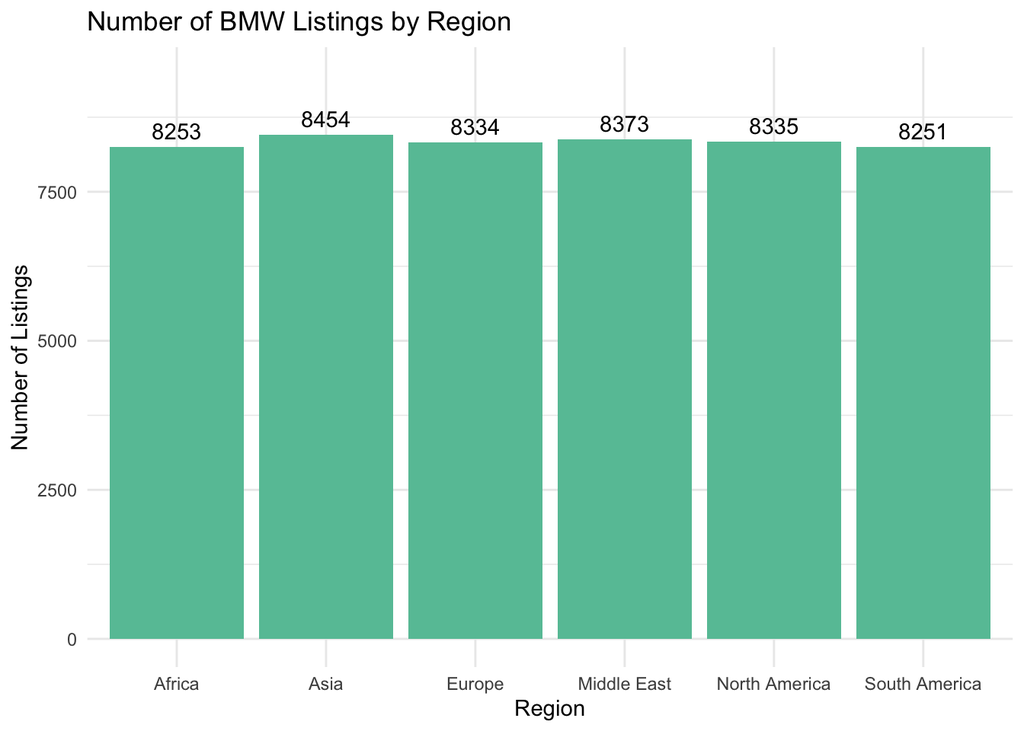

```r
library(dplyr)
library(ggplot2)
library(tidyr)
library(kableExtra)
df <- read.csv("BMW_sales_data (2010-2024).csv")

region_count <- df %>%
  group_by(Region) %>%
  summarise(Count = n())

ggplot(region_count, aes(x = Region, y = Count))+
  geom_bar(stat = "identity",fill = "#66c2a5")+
  geom_text(aes(label = Count), vjust = -0.5)+
  scale_y_continuous(limits = c(0, max(region_count$Count) + 1000))+
  labs(
       title = "Number of BMW Listings by Region",
       x = "Region",
       y = "Number of Listings")+
  theme_minimal()
```

This plot shows how many sales BMW made across different region in this dataset in total. The result presents that each region has a similar number of observations, ranging from approximately 8,200 to 8,450, which indicates that the dataset is relatively balanced. This is important to know becuase we can compare prices across regions directly without worrying that a region with more data will dominate the analysis.

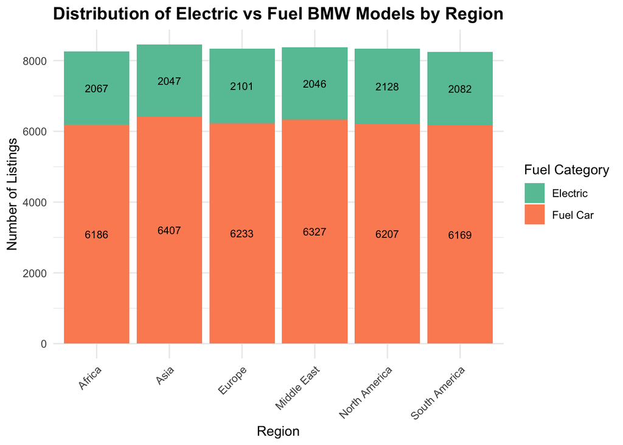

```r
df <- df %>%
  mutate(Fuel_Category = ifelse(Fuel_Type == "Electric", "Electric", "Fuel Car"))

fuel_distribution <- df %>%
  group_by(Region, Fuel_Category) %>%
  summarise(Count = n()) %>%
  ungroup()
ggplot(fuel_distribution, aes(x = Region, y = Count, fill = Fuel_Category))+
  geom_bar(stat = "identity")+
  geom_text(aes(label = Count), position = position_stack(vjust = 0.5), size = 3)+
  labs(
    title = "Distribution of Electric vs Fuel BMW Models by Region",
    x = "Region",
    y = "Number of Listings",
    fill = "Fuel Category"
  )+
  theme_minimal()+
  theme(
    plot.title = element_text(hjust = 0.5, size = 14, face = "bold"),
    axis.text.x = element_text(angle = 45, hjust = 1)
  )+
  scale_fill_manual(values = c("Electric" = "#66c2a5", "Fuel Car" = "#fc8d62"))
```

This chart shows the distribution of BMW models by fuel type in different rigion. From the chart we can see that Fuel Car dominate about 75% of the market in across all region.This indicate that consumers around the world still prefer BMW’s traditional fuel car more than electric car. Moverover, the proportion of fuel cars to electric vehicles is similar across all regions, indicating that BMW maintains a relatively consistent product mix worldwide.

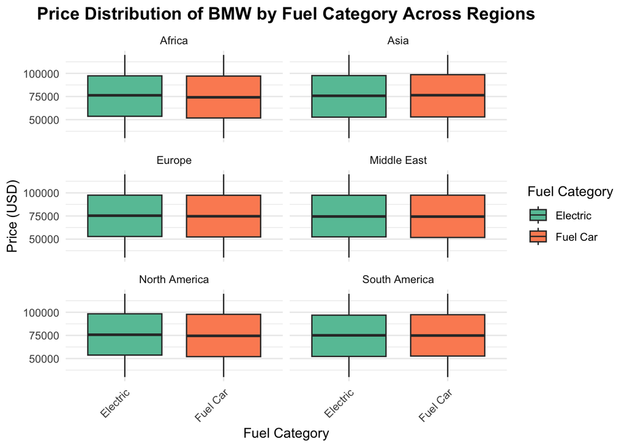

```r
ggplot(df, aes(x = Fuel_Category, y = Price_USD, fill = Fuel_Category)) +
  geom_boxplot() +
  facet_wrap(~Region, ncol = 2) +
  labs(
    title = "Price Distribution of BMW by Fuel Category Across Regions",
    x = "Fuel Category",
    y = "Price (USD)",
    fill = "Fuel Category"
  )+
  scale_fill_manual(values = c("Fuel Car" = "#fc8d62", "Electric" = "#66c2a5"))+
  theme_minimal()+
  theme(
    plot.title = element_text(hjust = 0.5, size = 14, face = "bold"),
    axis.text.x = element_text(angle = 45, hjust = 1)
  )
```

The boxplot shows the price distribution of BMW models by fuel category (Fuel Car vs Electric) across six regions. As the plots show, the price ranges for electric and fuel vehicles are nearly same within each region. Furthermore, the overall distribution of fuel cars and electric vehicles is consistent across regions, indicating that BMW maintains a similar product mix worldwide. This suggests that regional market does not significantly influence BMW’s pricing strategy, and the proportion of electric to fuel vehicles remains stable regardless of location. So that we can say that at least in this scope of data, BMW pricing strategy is globally approach rather than region specific approach.

## Statistical Analysis and Interpretation

```r
model1 <- lm(Price_USD ~ Year + Fuel_Category, data = df)
summary(model1)
```

```
Call:
lm(formula = Price_USD ~ Year + Fuel_Category, data = df)

Residuals:
   Min     1Q Median     3Q    Max
-45340 -22617    -48  22588  45174

Coefficients:
                      Estimate Std. Error t value Pr(>|t|)
(Intercept)           32214.95   54230.50   0.594    0.552
Year                     21.35      26.89   0.794    0.427
Fuel_CategoryFuel Car  -322.18     268.72  -1.199    0.231

Residual standard error: 26000 on 49997 degrees of freedom
Multiple R-squared:  4.134e-05, Adjusted R-squared:  1.334e-06
F-statistic: 1.033 on 2 and 49997 DF,  p-value: 0.3558
```

```r
coeffs <- summary(model1)$coefficients
model1_table <- data.frame(
  Term = rownames(coeffs),
  Estimate = coeffs[,1],
  Std_Error = coeffs[,2],
  t_value = coeffs[,3],
  p_value = coeffs[,4]
)

print(model1_table)
```

```
                                       Term   Estimate   Std_Error    t_value
(Intercept)                     (Intercept) 32214.9537 54230.49994  0.5940376
Year                                   Year    21.3491    26.88633  0.7940505
Fuel_CategoryFuel Car Fuel_CategoryFuel Car  -322.1818   268.71677 -1.1989643
                        p_value
(Intercept)           0.5524897
Year                  0.4271698
Fuel_CategoryFuel Car 0.2305475
```

This regression model examines how BMW prices are affected by Year and Fuel Category. The intercept 32,215 USD represents the estimated base price. The coefficient for Year (21.35) suggests that every year the average prices of BMW increase about $21on, but this is not statistically significant becuase the p-value is 0.427, indicating that year-to-year changes are minor. The coefficient for Fuel Car is -322.18 USD with p = 0.231, meaning fuel cars are on average slightly cheaper than electric vehicles, but the difference is not statistically significant.

Overall, this result shows that BMW’s pricing does not vary strongly over time or between electric and fuel vehicles in this dataset, supporting that BMW maintains a globally consistent pricing strategy rather than a region or fuel specific strategy.

```r
features <- df %>% select(Price_USD, Engine_Size_L, Mileage_KM, Year)
fuel <- df$Fuel_Category

features_scaled <- scale(features)

pcaModel <- prcomp(features_scaled)
pcaDF <- data.frame(
  PC1 = pcaModel$x[,1],
  PC2 = pcaModel$x[,2],
  Fuel_Category = fuel,
  Price_USD = df$Price_USD
)
pca_summary <- summary(pcaModel)$importance
print(pca_summary)
```

```
                           PC1     PC2       PC3       PC4
Standard deviation     1.00548 1.00135 0.9990203 0.9941153
Proportion of Variance 0.25275 0.25068 0.2495100 0.2470700
Cumulative Proportion  0.25275 0.50342 0.7529300 1.0000000
```

This PCA model examines how the main features of BMW vehicles, Engine Size, Mileage, Year, and Price, relate to each other and whether they separate electric and fuel cars.From the result we can see that proportion of variance for each factor is around 25% (PC1 = 25.3%, PC2 = 25.1%, PC3 = 24.9%, PC4 = 24.7%), indicating that no single combination of features dominate the price.This result suggests that BMW’s pricing strategy does not rely on individual vehicle characteristics. Overall, with the regression analysis from Model 1, it supports the conclusion that BMW maintains a relatively consistent, globally uniform pricing strategy, with only minor differences between electric and fuel vehicles.

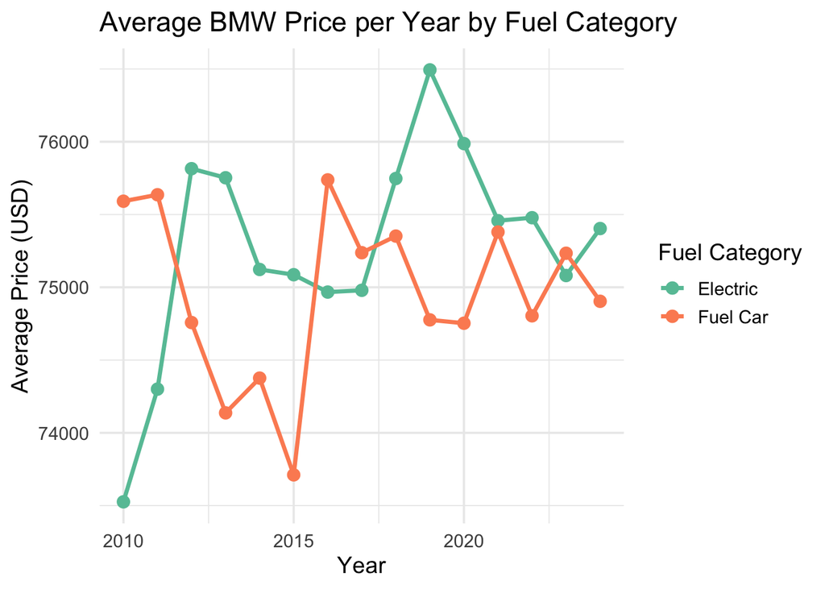

```r
df_summary <- df %>%
  group_by(Year, Fuel_Category) %>%
  summarise(Mean_Price = mean(Price_USD), .groups = "drop")

ggplot(df_summary, aes(x = Year, y = Mean_Price, color = Fuel_Category))+
  geom_point(size = 3)+
  geom_line(size = 1.2)+
  scale_color_manual(values = c("#66c2a5", "#fc8d62"))+
  labs(
    title = "Average BMW Price per Year by Fuel Category",
    x = "Year",
    y = "Average Price (USD)",
    color = "Fuel Category"
  )+
  theme_minimal(base_size = 14)
```

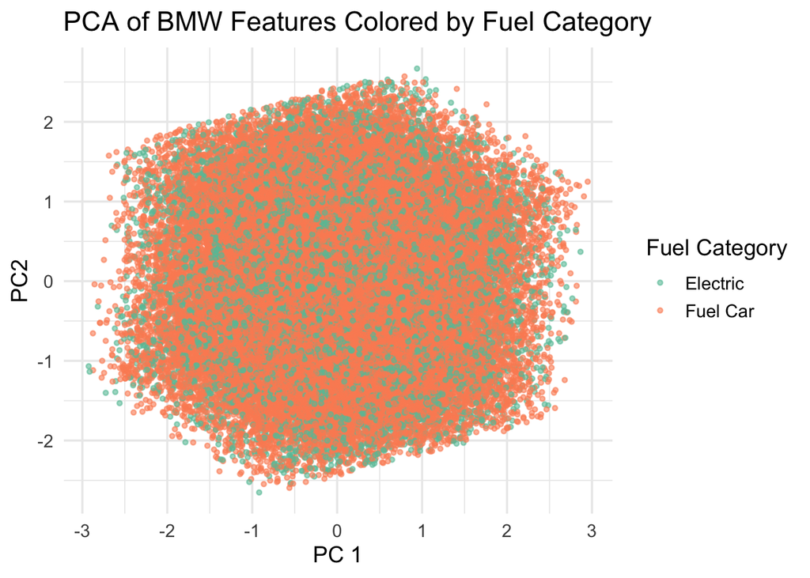

```r
ggplot(pcaDF, aes(x = PC1, y = PC2, color = Fuel_Category))+
  geom_point(alpha = 0.6, size = 1) +
  labs(
    title = "PCA of BMW Features Colored by Fuel Category",
    x = "PC 1",
    y = "PC2",
    color = "Fuel Category"
  )+
  scale_color_manual(values = c("Fuel Car" = "#fc8d62", "Electric" = "#66c2a5"))+
  theme_minimal(base_size = 14)
```

This plot shows BMW vehicles distribution of the first two principal components. From the plot, we can see that Electric and Fuel Cars are mostly overlap, meaning there is no clear separation. This suggests that these features do not strongly determine the difference in pricing between Electric and Fuel Cars.

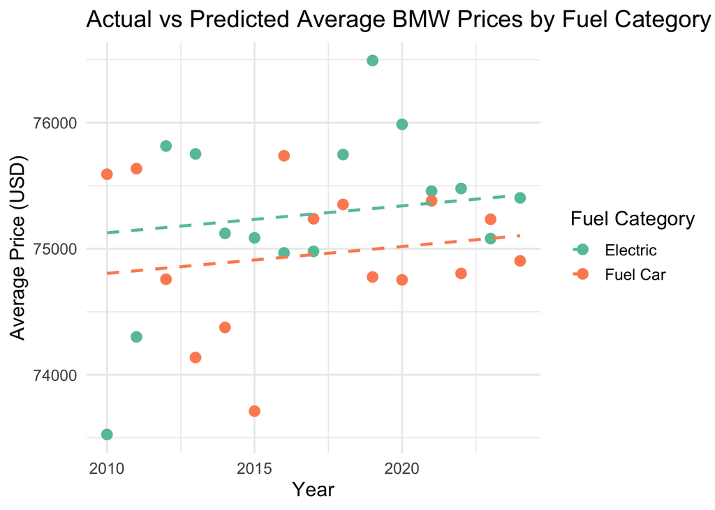

```r
df <- df %>%
  mutate(Predicted_Price = predict(model1, newdata = df))

df_summary <- df %>%
  group_by(Year, Fuel_Category) %>%
  summarise(
    Actual_Mean = mean(Price_USD),
    Predicted_Mean = mean(Predicted_Price),
    .groups = "drop"
  )

ggplot(df_summary, aes(x = Year))+
  geom_point(aes(y = Actual_Mean, color = Fuel_Category), size = 3)+
  geom_line(aes(y = Predicted_Mean, color = Fuel_Category), linetype = "dashed", size = 1)+
  scale_color_manual(values = c("Electric" = "#66c2a5", "Fuel Car" = "#fc8d62"))+
  labs(
    title = "Actual vs Predicted Average BMW Prices by Fuel Category",
    x = "Year",
    y = "Average Price (USD)",
    color = "Fuel Category"
  )+
  theme_minimal(base_size = 14)
```

## Conclusions

Based on the analysis of BMW sales data (2010–2024), it is clear that BMW employs a relatively consistent pricing strategy across both fuel types and regions. The PCA analysis indicates that BMW does not base its pricing on any single feature of the vehicles. This approach is highly suitable for a large company like BMW, which offers a wide variety of products and engages in a global market.

Furthermore, the automotive industry is highly complex and influenced by local policies, government subsidies, tariffs, and other global factors, such as oil prices. All of these factors can greatly affect vehicle sales. In this context, the results of this research can be use as strong evidence that BMW employs a consistent, universal pricing strategy. Which aligns with the global marketing standardization perspective discussed by Zou and Cavusgil (2002). As Zou and Cavusgil note, “the standardization perspective emphasizes how much a firm’s product, promotion, channel structure, and price are standardized across the country markets,” highlighting that multinational firms often seek consistent pricing across regions.

However, to fully understand the automotive market or to predict future prices, it would be necessary to collect more detailed and larger-scale data on regional promotions, dealer networks, and local demand.

## Project Reflection}

In this project, I used a BMW sales dataset from Kaggle. Since the dataset was already clean and most the variables is clear. So the data cleaning and wrangling process did not take me much time. One of my concern from begining was if the number of data from each region is different, it could introduce bias if one region dominate the dataset. So my first visalization compared how many sales BMW made across different region in this dataset in total. The result is that the counts of data from different region is mostly similar. Which reassured me that no single region would disproportionately influence the results.

The most effective plot I created in this project would be my Visual 3, a boxplot showing the price distribution of BMW models by fuel category across six regions. From this plot I concluded that bmw is using a consistent pricing strategy across both region and fuel type. All the models and visualiaztions that followed were designed to provide more evidence to support this conclusion. And I found it really effective becuase with one visuliazation I presents the price distribution across six regions.

During this project, one rule I was following the whole time is: always stay aligned with my research question. I wrote the topic on a sticky note and sticked it on my computer. Every after time I finished one plot or finished one interpretation, I revisited the note and check whether what I got were still conected to my topic and help a better understanding for my project. This kept my visualiaztions and interpretations on track. Becuase from the previoous expriences, I know that when working on a large project with multiple components, it is very easy to get lost of topic and unintentionally shift away from the original goal. This strategy helped prevent that from happening.

One fun thing in this project was choosing the colors for my plots. In past labs, I felt my color palettes were either too harsh or not attractive enough. Last week, by coincidence, I was watching a Miami Dolphins game highlight on YouTube, and I realized that the blue and orange in their uniforms were both eye catching and comfortable to read. Inspired by that combination, I decided to use those colors in my plots for this project. For me, the visual presentation in this project turned out very satisfying.

At the beginning of the project, I noticed that the plot I created showed a strong pattern of consistency across regions and fuel types. This was very different from what I originally expected. I had predicted that there would be large regional differences, and that electric and fuel-powered cars would follow completely different pricing strategies. I initially hoped to discover a big differences then I could provid rich business analysis. Because of this, I was disappointed with my early plots and even questioned whether there were mistakes in the data or in my visualizations. However, as I continued creating additional plots, each one keep supporting the idea of a unified pricing strategy. This gradually convinced me that BMW truly follows a standardized approach. I also began to understand that such consistency is reasonable and beneficial, as it helps maintain a strong and coherent brand image across global markets.

## Works Cited

Eshummalik. (2024). BMW sales dataset (2010–2024) [Data set]. Kaggle. https://www.kaggle.com/datasets/eshummalik/bmw-sales-dataset?resource=download

Zou, S., & Cavusgil, S. T. (2002). The GMS: A broad conceptualization of global marketing strategy. *Journal of Marketing*, 66(4), 40–56.